# Machine Learning in Python - Project 1

## 4. Discussion

My final model is kernel ridge regression model with polynomial kernel of degree 2. This model will take the feature into higher demension, calculate the dual coeffient and then use dual coeffient and kernel feature to do prediction. The kernel feature consider the non-linear property of feature similarity which is better than only use linear feature in other models. It also account for the feature interaction. The data used for this model has both nemeric data and categorical data (only zero and one) and only numeric data are standard scaled. I also use log scale of `sale_price` and `lot_area` because they are right skewed and using log scale will make prediction better. below is my model performance for test data.

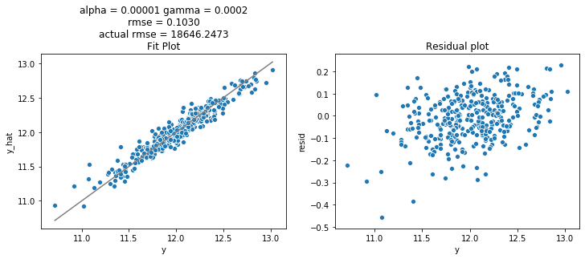

```
18646.2473
```

```python
model_fit(m, X_test, y_test, alpha = m.best_estimator_.alpha,
              gamma = m.best_estimator_.gamma, plot=True)
```

```python
#model coefficient
w = m.best_estimator_.dual_coef_
print('The dual coeffient is:\n {}'.format(w))
```

```
The dual coeffient is:
 [3144.54796534  215.85205509  627.18413869 ...  156.81052242 3926.2585967
  204.78647061]
```

```python
params = m.best_params_
kernel_feature = pairwise_kernels(m.best_estimator_.X_fit_, metric='poly',
                                  filter_params=True, **params)
print('The kernel feature is:\n {}'.format(kernel_feature))
```

```
The kernel feature is:
 [[1.01265775 1.0051582  1.0055382  ... 1.00362556 1.00196004 1.00553472]
 [1.0051582  1.00823419 1.00418756 ... 1.00582694 1.00532858 1.00555172]
 [1.0055382  1.00418756 1.00796288 ... 1.0050097  1.00341876 1.0042897 ]
 ...
 [1.00362556 1.00582694 1.0050097  ... 1.00732784 1.00534728 1.00598794]
 [1.00196004 1.00532858 1.00341876 ... 1.00534728 1.01011983 1.00559101]
 [1.00553472 1.00555172 1.0042897  ... 1.00598794 1.00559101 1.00635073]]
```

```python
prediction = w @ kernel_feature
print('The prediction is:\n {}'.format(prediction))
```

```
The prediction is:
 [12.25927978 12.25843483 12.25829432 ... 11.91721425 11.74316569
 12.10834241]
```

```python
print('The shape of dual coefficient is:\n {}\nThe shape of kernel feature is:\n {}\n\
The shape of prediction is:\n {}'.format(w.shape, kernel_feature.shape, prediction.shape))
```

```
The shape of dual coefficient is:
 (1584,)
The shape of kernel feature is:
 (1584, 1584)
The shape of prediction is:
 (1584,)
```

The polynomial kernel will increase the number of features, these feature is constructed by the original feature and has strong relationship to the original feature. The higher dual coeffient means more significant the corresponding kernel feature. This model is better than linear regression, so it is accurate and useful.

## 5. Model Validation

When a new house come, this model may give a prediction with an uncertainty of nearly `$19000`. This model will take all the information provided except the `year_sold` and a new variable `nb_level` which means the price level of each neighborhood. The model is predicting the log sclae sale price, so before calculating the root mean squared error, I exponential it to the real scale.

```python
sales_holdout = pd.read_csv("sales_holdout.csv")

#Preprocess the holdout data
obj = data_analysis(sales, sales_holdout)
X_sales, y_sales, X_holdout, y_holdout = obj.process()
final_model = best_param(X_sales, y_sales, X_holdout, y_holdout)
```

```python
# Calculate the root mean squared error for your model


print('The RMSE of predicted price is: {}'.format(
    np.sqrt( sklearn.metrics.mean_squared_error(np.exp(y_holdout),
                                                np.exp(final_model.predict(X_holdout))))
))
```

```
The RMSE of predicted price is: 18646.247302896096
```